# RahulBurjanroppaProject_Full_Code_Notebook_EasyVisa

# **Data Pre-Processing**

To get the dataset ready for efficient modeling, data pre-processing was done. By resolving missing values, outliers, and feature changes as needed, this stage guarantees that the data is clean, consistent, and appropriate for machine learning algorithms.

```python
# Copy df for preprocessing stage
df_pre = df.copy()

# Analyze basic info
df_pre.shape, df_pre.info()
```

```
<class 'pandas.core.frame.DataFrame'>
RangeIndex: 25480 entries, 0 to 25479
Data columns (total 12 columns):
 #   Column                 Non-Null Count  Dtype
---  ------                 --------------  -----
 0   case_id                25480 non-null  object
 1   continent              25480 non-null  object
 2   education_of_employee  25480 non-null  object
 3   has_job_experience     25480 non-null  object
 4   requires_job_training  25480 non-null  object
 5   no_of_employees        25480 non-null  int64
 6   yr_of_estab            25480 non-null  int64
 7   region_of_employment   25480 non-null  object
 8   prevailing_wage        25480 non-null  float64
 9   unit_of_wage           25480 non-null  object
 10  full_time_position     25480 non-null  object
 11  case_status            25480 non-null  object
dtypes: float64(1), int64(2), object(9)
memory usage: 2.3+ MB
```

```
((25480, 12), None)
```

#### **Missing Values Handing**

```python
# Check for missing vals
df_pre.isnull().sum()
```

|  | 0 |
| --- | --- |
| case_id | 0 |
| continent | 0 |
| education_of_employee | 0 |
| has_job_experience | 0 |
| requires_job_training | 0 |
| no_of_employees | 0 |
| yr_of_estab | 0 |
| region_of_employment | 0 |
| prevailing_wage | 0 |
| unit_of_wage | 0 |
| full_time_position | 0 |
| case_status | 0 |

**dtype:** int64

No missing values were found and therefore, no missing values require handling.

#### **Outlier Detection and Handling**

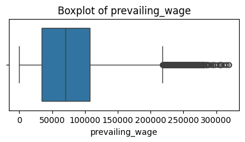

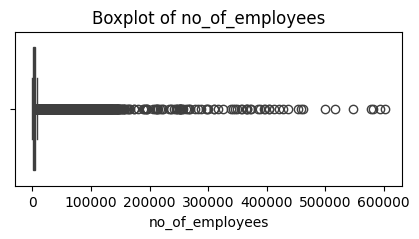

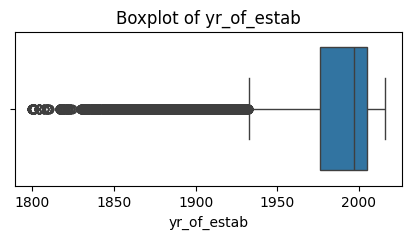

```python
numerical_cols = ["prevailing_wage", "no_of_employees", "yr_of_estab"]

for col in numerical_cols:
    plt.figure(figsize=(5, 2))
    sns.boxplot(x=df_pre[col])
    plt.title(f"Boxplot of {col}")
    plt.show()
```

```python
# Log transform prevailing wage due to heavy right skew
df_pre["prevailing_wage"] = np.log1p(df_pre["prevailing_wage"])
df_pre["no_of_employees"] = np.log1p(df_pre["no_of_employees"])
```

## **Feature Engineering**

```python
# Convert target variable to binary
df_pre["case_status"] = df_pre["case_status"].map({"Denied": 0, "Certified": 1})
# One-hot encode categorical variables
df_pre = pd.get_dummies(df_pre, drop_first=True)
```

The target variable was transformed into a binary format appropriate for categorization as part of feature engineering. To enable machine learning models to read non-numeric data without enforcing ordinal connections, categorical variables were converted via one-hot encoding.

## **Preparation of Data for Modeling**

```python
X = df_pre.drop("case_status", axis=1)
y = df_pre["case_status"]

X_train, X_test, y_train, y_test = train_test_split(
    X, y,
    test_size=0.2,
    stratify=y,
    random_state=42
)
```

An 80–20 split was used to divide the dataset into training and testing sets. Because of the observed class imbalance in visa certification outcomes, stratified sampling was used to maintain the original class distribution.